# ミュラー・リヤー錯視実験

Author

藤原 蓮(2412C11)

## 1. 目的 (Introduction)

本研究では、ミュラー・リヤー錯視（Müller-Lyer illusion）における視覚的特徴の影響について検討する。ミュラー・リヤー錯視とは、同じ物理的長さを持つ線分であっても、その両端に付けられた矢羽の形状や角度によって、線の長さが異なって知知覚される視覚的錯視現象である（([SHIMADA 1952](https://a9dffa4913d44001af3f03a4eae6fdcb.app.posit.cloud/p/4e21e68c/#ref-shimada1952))）。 先行研究においては、矢羽の角度が鋭角であるほど、また矢羽の長さが長いほど錯覚量が大きくなることが示されている。これは、脳内での情報処理において矢羽を含めた全体的な領域の空間的広がりが統合されて知覚されるためだと説明される。

本実験の目的は、オンライン実験プラットフォーム上においても、矢羽の角度および長さが錯覚量に与える影響が再現されるかを検証することである。本実験では、以下の2つの仮説を設定した。

仮説1（角度の主効果）: 矢羽の角度が鋭角（15度）の条件は、鈍角（75度）の条件よりも錯覚量が大きくなる。

仮説2（長さの主効果）: 矢羽の長さが長条件（50 px）は、短条件（20 px）よりも錯覚量が大きくなる。

## 2. 方法 (Method)

### 参加者

２０名のデータを収集した。

### 装置と材料

オンライン実験プラットフォーム（jsPsych）を使用した。実験刺激として、主線分に矢羽が付加されたミュラー・リヤー図形を用いた。独立変数として、矢羽の角度（15度 / 75度）の2水準、および矢羽の長さ（20 px / 50 px）の2水準を設定した（計4条件の参加者内デザイン）。従属変数は、主観的等価点（PSE）から算出された平均錯覚量（px）の絶対値とした。

### 手続き

実験はWebブラウザ上で個別に行われた。各試行において、参加者には標準刺激と比較刺激が提示された。参加者は、キーボード操作等を用いて比較刺激の線分の長さを調整し、標準刺激と同じ長さに見える地点で回答を確定するよう求められた。

全4条件（15度/20px、15度/50px、75度/20px、75度/50px）の刺激がランダムな順序で複数回提示され、測定された錯覚量の平均値を個人の各条件のデータとして記録した。

## 3. 結果 (Results)

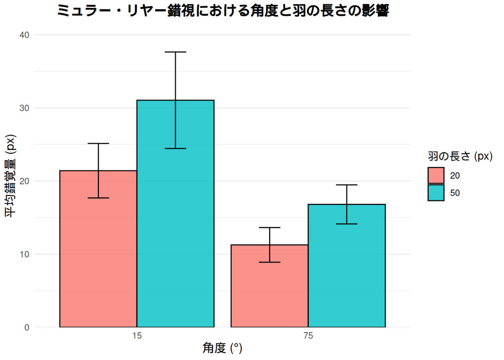

## 4. 考察 (Discussion)

本実験の限界と課題として、以下の2点が挙げられる。

- **画面環境の不統一**: オンライン実験（jsPsych）のため、参加者のディスプレイサイズや観察距離を統制できず、ピクセル（px）指定が物理的な視角として一定でなかった可能性がある。
- **条件設定の限定**: 角度2水準・長さ2水準のみの検討にとどまったため、連続的な錯覚量の変化パターンまでは把握できていない。

今後は、画面サイズの自動キャリブレーションの導入や、角度・長さを多段階に設定した検証が課題とされる。

## 5. 引用文献 (References)